# Fatores associados à hospitalização por infecção

# 🔹 Modelo 4 (Remoção de ‘diabetes’ e ‘doença pulmonar’)

O modelo 4 incluiu apenas faixa etária, IMC e tabagismo. Este modelo apresentou o menor AIC, boa estabilidade das estimativas e interpretação epidemiológica clara.

Embora IMC e tabagismo não tenham atingido significância estatística convencional (p < 0,05), ambos foram mantidos como ajustes conceituais relevantes, evitando viés de confusão.

A faixa etária ≥60 anos permaneceu como o principal fator associado à hospitalização, com odds ratio elevado e consistente em todos os modelos.

```r
############################################################

# 18. MODELO 4 — FAIXA ETÁRIA + IMC + TABAGISMO

############################################################

modelo_4 <- glm(
hospitalizado ~ faixa_etaria + imc_faixa + tabagista,
data = treino,
family = binomial
)

summary(modelo_4)
```

```
##
## Call:
## glm(formula = hospitalizado ~ faixa_etaria + imc_faixa + tabagista,
##     family = binomial, data = treino)
##
## Coefficients:
##                    Estimate Std. Error z value Pr(>|z|)
## (Intercept)         -2.8342     0.8431  -3.362 0.000775 ***
## faixa_etaria40–59    1.3413     0.8743   1.534 0.124964
## faixa_etaria60+      1.8224     0.8693   2.096 0.036059 *
## imc_faixaObesidade   0.9399     0.7960   1.181 0.237727
## imc_faixaSobrepeso   1.2657     0.6746   1.876 0.060609 .
## tabagista           -0.7765     0.6025  -1.289 0.197471
## ---
## Signif. codes:  0 '***' 0.001 '**' 0.01 '*' 0.05 '.' 0.1 ' ' 1
##
## (Dispersion parameter for binomial family taken to be 1)
##
##     Null deviance: 99.880  on 85  degrees of freedom
## Residual deviance: 86.565  on 80  degrees of freedom
## AIC: 98.565
##
## Number of Fisher Scoring iterations: 5
```

### Comparação: Modelo 4 x Modelo 3

```r
anova(modelo_3, modelo_4, test = "Chisq")
```

|  | Resid. Df | Resid. Dev | Df | Deviance | Pr(>Chi) |
| --- | --- | --- | --- | --- | --- |
| 1 | 78 | 83.79093 | NA | NA | NA |
| 2 | 80 | 86.56459 | -2 | -2.773664 | 0.2498656 |

### AIC e Pseudo R²

```r
data.frame(
Modelo = "Modelo 4 (Faixa Etária + IMC + Tabagismo)",
AIC = AIC(modelo_4),
McFadden_R2 = 1 - modelo_4$deviance / modelo_4$null.deviance
)
```

| Modelo | AIC | McFadden_R2 |
| --- | --- | --- |
| Modelo 4 (Faixa Etária + IMC + Tabagismo) | 98.56459 | 0.1333143 |

### Odds Ratio e IC

```r
OR_4 <- exp(coef(modelo_4))
IC_4 <- exp(confint(modelo_4))

data.frame(
Variavel = names(OR_4),
OR = round(OR_4, 3),
IC_Inf = round(IC_4[,1], 3),
IC_Sup = round(IC_4[,2], 3)
)
```

|  | Variavel | OR | IC_Inf | IC_Sup |
| --- | --- | --- | --- | --- |
| (Intercept) | (Intercept) | 0.059 | 0.008 | 0.242 |
| faixa_etaria40–59 | faixa_etaria40–59 | 3.824 | 0.790 | 28.382 |
| faixa_etaria60+ | faixa_etaria60+ | 6.186 | 1.300 | 45.712 |
| imc_faixaObesidade | imc_faixaObesidade | 2.560 | 0.548 | 13.113 |
| imc_faixaSobrepeso | imc_faixaSobrepeso | 3.546 | 0.998 | 14.819 |
| tabagista | tabagista | 0.460 | 0.129 | 1.426 |

### Curva ROC

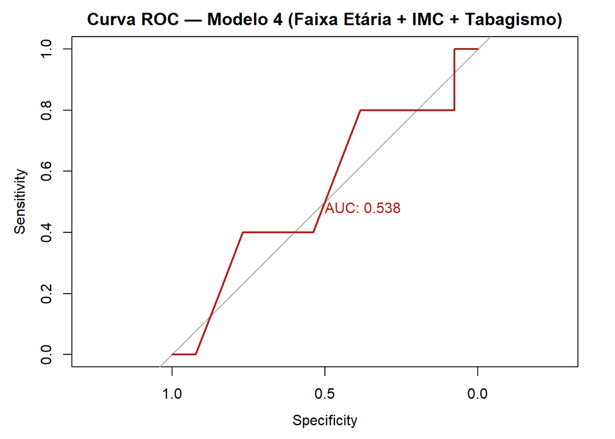

```r
teste$prob_4 <- predict(modelo_4, newdata = teste, type = "response")
roc_4 <- roc(teste$hospitalizado, teste$prob_4)

plot(
roc_4,
print.auc = TRUE,
col = "firebrick",
main = "Curva ROC — Modelo 4 (Faixa Etária + IMC + Tabagismo)"
)
```

# 🔹 Conclusão: Qual modelo usar?

O Modelo 4 (Faixa Etária + IMC + Tabagismo) foi escolhido. Este modelo não deve ser interpretado como um classificador clínico, devido ao tamanho amostral reduzido e aos intervalos de confiança amplos. No entanto, ele se mostra adequado como modelo epidemiológico:

- Identifica fatores associados de forma consistente;
- Evita overfitting;
- Mantém interpretabilidade clínica;
- Segue uma estratégia analítica transparente e reprodutível.